# Further EDA

## 今天要來探討的是在新德里的餐廳裡，影響網路評分的因素。

#### 我們先匯入資料，並看看我們的dataset長什麼樣子

```r
zomato <- read.csv("~/Github/CSX_RProject_Summer_2018/week_4/zomato-restaurants-data/zomato.csv")
summary(zomato)
```

```
##  Restaurant.ID              Restaurant.Name  Country.Code
##  Min.   :      53   Cafe Coffee Day :  83   Min.   :  1.00
##  1st Qu.:  301962   Domino's Pizza  :  79   1st Qu.:  1.00
##  Median : 6004089   Subway          :  63   Median :  1.00
##  Mean   : 9051128   Green Chick Chop:  51   Mean   : 18.37
##  3rd Qu.:18352292   McDonald's      :  48   3rd Qu.:  1.00
##  Max.   :18500652   Keventers       :  34   Max.   :216.00
##                     (Other)         :9193
##         City
##  New Delhi:5473
##  Gurgaon  :1118
##  Noida    :1080
##  Faridabad: 251
##  Ghaziabad:  25
##  Ahmedabad:  21
##  (Other)  :1583
##                                                                        Address
##  Dilli Haat, INA, New Delhi                                                :  11
##  Sector 41, Noida                                                          :  11
##  Greater Kailash (GK) 1, New Delhi                                         :  10
##  The Imperial, Janpath, New Delhi                                          :   9
##  Cyber Hub, DLF Cyber City, Gurgaon                                        :   8
##  Food Court, 3rd Floor, Logix City Centre, Sector 32, Near Sector 34, Noida:   8
##  (Other)                                                                   :9494
##             Locality                      Locality.Verbose
##  Connaught Place: 122   Connaught Place, New Delhi: 122
##  Rajouri Garden :  99   Rajouri Garden, New Delhi :  99
##  Shahdara       :  87   Shahdara, New Delhi       :  87
##  Defence Colony :  86   Defence Colony, New Delhi :  86
##  Malviya Nagar  :  85   Pitampura, New Delhi      :  85
##  Pitampura      :  85   Malviya Nagar, New Delhi  :  84
##  (Other)        :8987   (Other)                   :8988
##    Longitude          Latitude                       Cuisines
##  Min.   :-157.95   Min.   :-41.33   North Indian         : 936
##  1st Qu.:  77.08   1st Qu.: 28.48   North Indian, Chinese: 511
##  Median :  77.19   Median : 28.57   Chinese              : 354
##  Mean   :  64.13   Mean   : 25.85   Fast Food            : 354
##  3rd Qu.:  77.28   3rd Qu.: 28.64   North Indian, Mughlai: 334
##  Max.   : 174.83   Max.   : 55.98   Cafe                 : 299
##                                     (Other)              :6763
```

[output cut: 17 more lines]

```
##  Min.   :1.000   Min.   :0.000    Dark Green: 301   Average  :3737
##  1st Qu.:1.000   1st Qu.:2.500    Green     :1079   Excellent: 301
##  Median :2.000   Median :3.200    Orange    :3737   Good     :2100
##  Mean   :1.805   Mean   :2.666    Red       : 186   Not rated:2148
##  3rd Qu.:2.000   3rd Qu.:3.700    White     :2148   Poor     : 186
##  Max.   :4.000   Max.   :4.900    Yellow    :2100   Very Good:1079
##
##      Votes
##  Min.   :    0.0
##  1st Qu.:    5.0
##  Median :   31.0
##  Mean   :  156.9
##  3rd Qu.:  131.0
##  Max.   :10934.0
##
```

#### 我們可以看到佔大多數的餐廳是位於新德里。為了去除不同文化和習俗的變素，我們就只專注於新德里的餐廳。

```r
zomato$City <- as.character(zomato$City)

Delhi_food <- zomato %>%
  ungroup() %>%
  filter(., City == "New Delhi")
```

#### 我們來看看餐廳的分佈吧。

```r
CountriesMap <- qmap("New Delhi", color = "bw", legend = "topleft")
```

[figure not shown]

```r
CountriesMap +
  geom_point(aes(x = Longitude, y = Latitude),
             data = Delhi_food)
```

#### 我們先來看看網路外送會不會影響總評分。我們來看看在有沒有網路外送会不会有不同的總評分分佈。

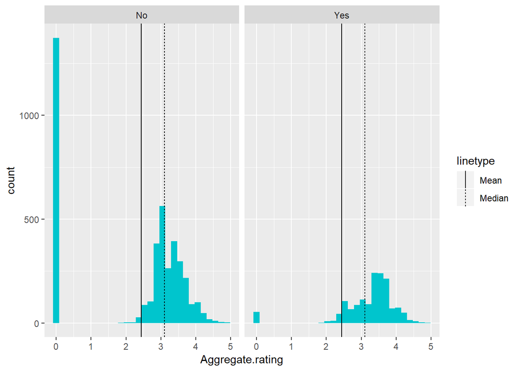

```r
ggplot(Delhi_food, aes(x = Aggregate.rating)) +
  geom_histogram(fill = "turquoise3") +
  facet_wrap(~Has.Online.delivery) +
  geom_vline(aes(xintercept = mean(Delhi_food$Aggregate.rating), linetype = "Mean")) +
  geom_vline(aes(xintercept = median(Delhi_food$Aggregate.rating), linetype = "Median"))
```

```r
print(mean(Delhi_food$Aggregate.rating))
```

```
## [1] 2.438845
```

```r
print(median(Delhi_food$Aggregate.rating))
```

```
## [1] 3.1
```

#### 看起來沒有外送很有可能會被給0分哦。

#### 不過我們得將兩個變數放入t-test 才能下定論。

#### *H0: 有沒有網路外送, 評分不受影響。*

#### *H1: 有沒有網路外送，評分會受影響。*

```r
t.test(Aggregate.rating ~ Has.Online.delivery, data = Delhi_food)
```

```
##
##  Welch Two Sample t-test
##
## data:  Aggregate.rating by Has.Online.delivery
## t = -33.688, df = 5034.3, p-value < 2.2e-16
## alternative hypothesis: true difference in means is not equal to 0
## 95 percent confidence interval:
##  -1.161642 -1.033876
## sample estimates:
##  mean in group No mean in group Yes
##          2.140186          3.237945
```

#### 從上述結果來看，我們可以說，**有和沒有網路外送的餐廳的平均評差異是顯著的**。（p 值少于 0.05）。

#### 我們現在再來看餐廳的價位是否會影響評價。我們以數據裡面，平均兩人餐花費的變數來代表價位吧。

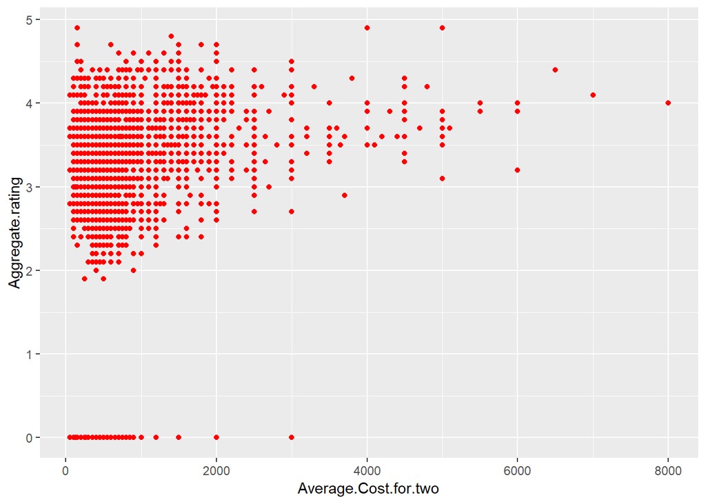

```r
ggplot(Delhi_food, aes(x = Average.Cost.for.two, y = Aggregate.rating)) +
  geom_point(colour = "red")
```

#### 我們先用correlation來看看兩個變數是否有關聯。必須用spearman，因為兩個變數的分佈都不是normal distribution。

```r
Delhi_food %>%
summarise(N = n(), r = cor(Aggregate.rating, Average.Cost.for.two, use = "pairwise.complete.obs", method = "spearman"))
```

```
##      N         r
## 1 5473 0.4337367
```

#### 哦。看起來還有點關聯哦。**似乎越貴，評價越高哦**。

。  
#### 我們再來看投票數吧，畢竟沒有被給評分的餐廳當然會零分。

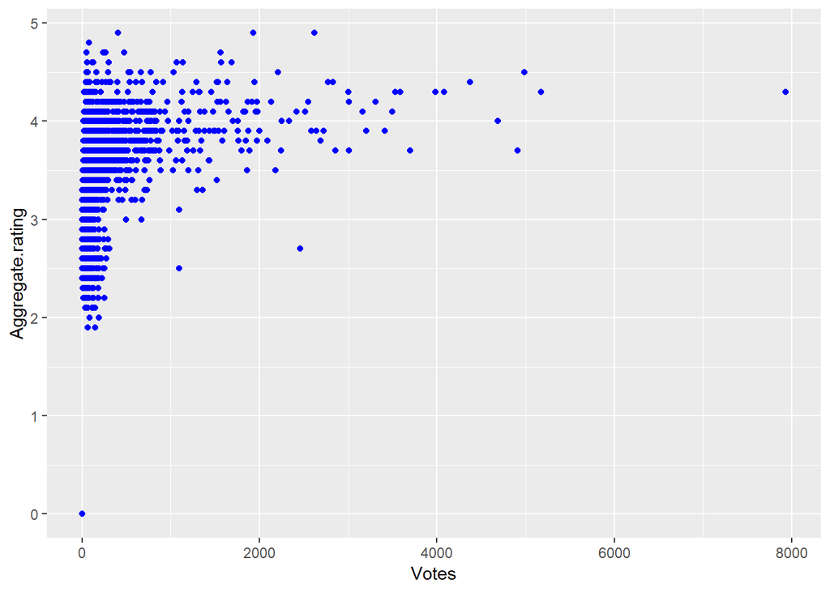

```r
ggplot(Delhi_food, aes(x = Votes, y = Aggregate.rating)) +
  geom_point(colour = "blue")
```

#### 我們再來跑一下correlation！

```r
Delhi_food %>%
  summarise(N = n(), r = cor(Aggregate.rating, Votes, use = "pairwise.complete.obs", method = "spearman"))
```

```
##      N         r
## 1 5473 0.8348706
```

#### 哦！有蠻大的關聯度喲！哦！**投票數和評分似乎有蠻大的關聯度喲**！

#### 我接下來再來看另一個價位的變數:1是檔次最低的一組餐廳，4是檔次最高的一組。

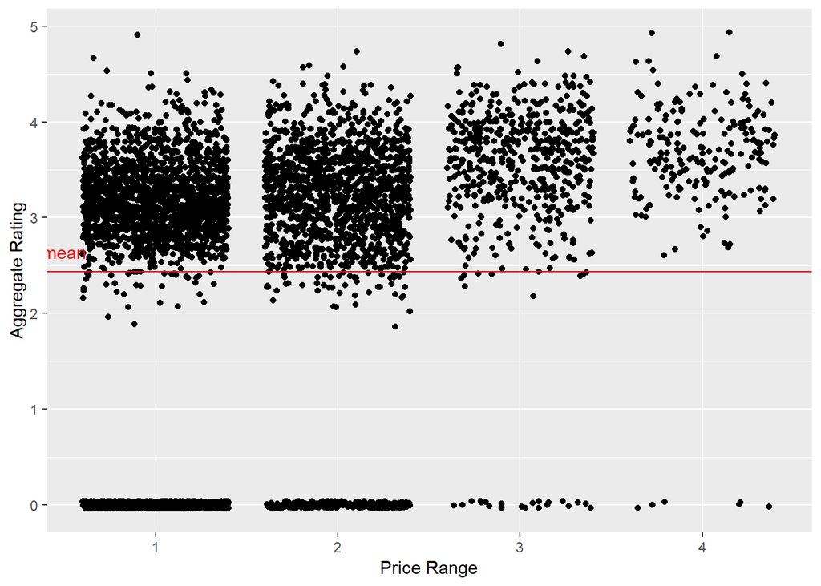

```r
Delhi_food$Price.range <- factor(Delhi_food$Price.range, levels = c(1, 2, 3, 4))

ggplot(data = Delhi_food,
       aes(x = Price.range, y = Aggregate.rating)) +
  geom_jitter(fill = "red") +
  geom_hline(yintercept = mean(Delhi_food$Aggregate.rating) ,
             linetype = 1, colour = "red") +
  labs(x = 'Price Range', y = 'Aggregate Rating') +
  annotate(geom="text", label="mean", x=0.5, y=mean(Delhi_food$Aggregate.rating), vjust=-1, colour = "red")
```

#### 我們來看看每組的平均評分.

```r
tapply(Delhi_food$Aggregate.rating, Delhi_food$Price.range, mean)
```

```
##        1        2        3        4
## 1.959666 2.837198 3.449909 3.585648
```

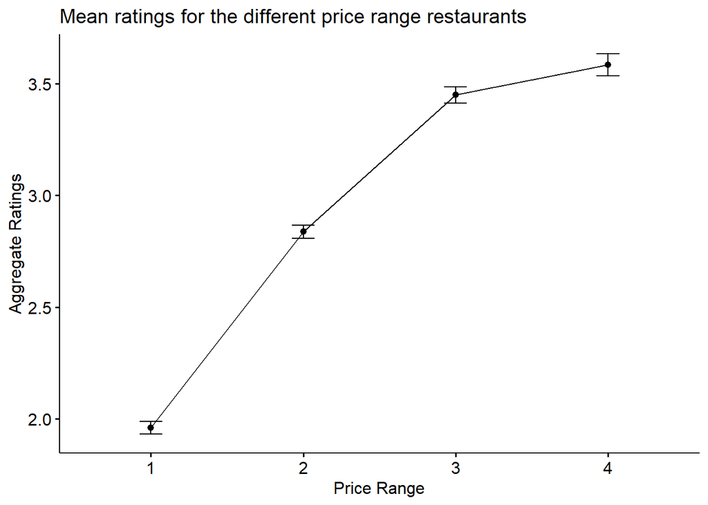

```r
ggline(Delhi_food, x = "Price.range", y = "Aggregate.rating",
  add = c("mean_se"),
  order = c(1, 2, 3, 4),
  ylab = "Aggregate Ratings", xlab = "Price Range") +
  ggtitle("Mean ratings for the different price range restaurants")
```

#### 現在我們就來檢查：

#### *H0: 不同價位的餐廳評分沒有明顯的差異。*

#### *H1: 不同價位的餐廳評分有明顯的差異。*

```r
price_anova <- aov(Aggregate.rating ~ Price.range, data = Delhi_food)
summary(price_anova)
```

```
##               Df Sum Sq Mean Sq F value Pr(>F)
## Price.range    3   1809   603.0   313.9 <2e-16 ***
## Residuals   5469  10504     1.9
## ---
## Signif. codes:  0 '***' 0.001 '**' 0.01 '*' 0.05 '.' 0.1 ' ' 1
```

#### 於是我們可以說**不同價位的餐廳評分有明顯的差異**.

#### 可是每組之間的差異都不一樣，所以我們必須繼續鑽研下去.

```r
TukeyHSD(price_anova)
```

```
##   Tukey multiple comparisons of means
##     95% family-wise confidence level
##
## Fit: aov(formula = Aggregate.rating ~ Price.range, data = Delhi_food)
##
## $Price.range
##          diff        lwr       upr     p adj
## 2-1 0.8775323  0.7688318 0.9862328 0.0000000
## 3-1 1.4902431  1.3251349 1.6553514 0.0000000
## 4-1 1.6259824  1.3752227 1.8767420 0.0000000
## 3-2 0.6127109  0.4373132 0.7881085 0.0000000
## 4-2 0.7484501  0.4907992 1.0061009 0.0000000
## 4-3 0.1357392 -0.1503183 0.4217968 0.6144854
```

#### 所有組跟組之間的比較，可以看出除了4-3的比較不顯著，(Confidence Interval 有0)，其他的比較都很顯著。 (Confidence Interval 沒有0)。

#### 接下來我們試著把以上的結果視覺化吧

```r
price_mod1 <- lm(Aggregate.rating ~ Price.range, data = Delhi_food)
summary(price_mod1)
```

```
##
## Call:
## lm(formula = Aggregate.rating ~ Price.range, data = Delhi_food)
##
## Residuals:
##     Min      1Q  Median      3Q     Max
## -3.5856 -1.9597  0.4628  1.0403  2.9403
##
## Coefficients:
##              Estimate Std. Error t value Pr(>|t|)
## (Intercept)   1.95967    0.02509   78.12   <2e-16 ***
## Price.range2  0.87753    0.04230   20.75   <2e-16 ***
## Price.range3  1.49024    0.06425   23.20   <2e-16 ***
## Price.range4  1.62598    0.09758   16.66   <2e-16 ***
## ---
## Signif. codes:  0 '***' 0.001 '**' 0.01 '*' 0.05 '.' 0.1 ' ' 1
##
## Residual standard error: 1.386 on 5469 degrees of freedom
## Multiple R-squared:  0.1469, Adjusted R-squared:  0.1464
## F-statistic: 313.9 on 3 and 5469 DF,  p-value: < 2.2e-16
```

```r
anova(price_mod1)
```

```
## Analysis of Variance Table
##
## Response: Aggregate.rating
##               Df  Sum Sq Mean Sq F value    Pr(>F)
## Price.range    3  1808.9  602.95  313.92 < 2.2e-16 ***
## Residuals   5469 10504.5    1.92
## ---
## Signif. codes:  0 '***' 0.001 '**' 0.01 '*' 0.05 '.' 0.1 ' ' 1
```

```r
confint(price_mod1)
```

```
##                  2.5 %    97.5 %
## (Intercept)  1.9104862 2.0088454
## Price.range2 0.7946097 0.9604548
## Price.range3 1.3642897 1.6161966
## Price.range4 1.4346895 1.8172752
```

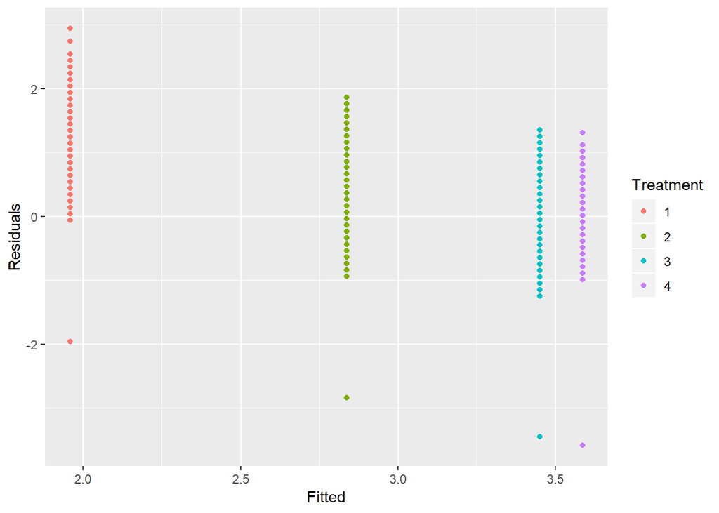

```r
price_mod = data.frame(Fitted = fitted(price_mod1),
                       Residuals = resid(price_mod1),
                       Treatment = Delhi_food$Price.range)

ggplot(price_mod, aes(Fitted, Residuals, colour = Treatment)) +
  geom_point()
```

#### 我们可以看到group3 和group4 的residual 跟fitted 的差异都不大。於是我們可以說**越高檔次的餐廳，越有可能得到好評，但效應會逐漸遞減。**